# final_Tsouprakos

```r
library(readxl)
library(repr)
library(dplyr)
library(corrplot)
library(cluster)
library(useful)
library(Hmisc)
library(HSAUR)
library(MVA)
library(HSAUR2)
library(fpc)
library(mclust)
library(lattice)
library(car)
library(ggplot2)
library(gridExtra)
library(maptree)
library(dendextend)
library(cluster)
```

```r
wine_dd <- read_excel('DataDictionary_WineSales.xlsx')
wine_dd <- wine_dd[c('VARIABLE NAME','DEFINITION')]
wine_dd <- na.omit(wine_dd)
wine_dd
```

| VARIABLE NAME | DEFINITION |
| --- | --- |
| INDEX | Identification Variable (do not use) |
| TARGET | Number of Cases Purchased |
| AcidIndex | Proprietary method of testing total acidity of wine by using a weighted average |
| Alcohol | Alcohol Content |
| Chlorides | Chloride content of wine |
| CitricAcid | Citric Acid Content |
| Density | Density of Wine |
| FixedAcidity | Fixed Acidity of Wine |
| FreeSulfurDioxide | Sulfur Dioxide content of wine |
| LabelAppeal | Marketing Score indicating the appeal of label design for consumers. High numbers suggest customers like the label design. Negative numbers suggest customes don't like the design. |

[output cut: 6 more lines]

```r
wine <- read_excel('WineSales.xlsx')
as.data.frame(t(head(wine)))
```

|  | V1 | V2 | V3 | V4 | V5 | V6 |
| --- | --- | --- | --- | --- | --- | --- |
| INDEX | 1.0000 | 2.00000 | 4.00000 | 5.0000 | 6.00000 | 7.0000 |
| TARGET | 3.0000 | 3.00000 | 5.00000 | 3.0000 | 4.00000 | 0.0000 |
| FixedAcidity | 3.2000 | 4.50000 | 7.10000 | 5.7000 | 8.00000 | 11.3000 |
| VolatileAcidity | 1.1600 | 0.16000 | 2.64000 | 0.3850 | 0.33000 | 0.3200 |
| CitricAcid | -0.9800 | -0.81000 | -0.88000 | 0.0400 | -1.26000 | 0.5900 |
| ResidualSugar | 54.2000 | 26.10000 | 14.80000 | 18.8000 | 9.40000 | 2.2000 |
| Chlorides | -0.5670 | -0.42500 | 0.03700 | -0.4250 | NA | 0.5560 |
| FreeSulfurDioxide | NA | 15.00000 | 214.00000 | 22.0000 | -167.00000 | -37.0000 |
| TotalSulfurDioxide | 268.0000 | -327.00000 | 142.00000 | 115.0000 | 108.00000 | 15.0000 |
| Density | 0.9928 | 1.02792 | 0.99518 | 0.9964 | 0.99457 | 0.9994 |

[output cut: 6 more lines]

```r
wine_desc <- describe(wine[,-c(1,2)])
cols <- names(wine_desc)
#wine_desc
```

```r
for (col in cols) {
  each_wine <- wine_desc[[col]]
  cat("\n", col, ", Missing Values: ", each_wine$counts['missing'])
}
```

```
##
##  FixedAcidity , Missing Values:  0
##  VolatileAcidity , Missing Values:  0
##  CitricAcid , Missing Values:  0
##  ResidualSugar , Missing Values:  616
##  Chlorides , Missing Values:  638
##  FreeSulfurDioxide , Missing Values:  647
##  TotalSulfurDioxide , Missing Values:  682
##  Density , Missing Values:  0
##  pH , Missing Values:  395
##  Sulphates , Missing Values:  1210
##  Alcohol , Missing Values:  653
##  LabelAppeal , Missing Values:  0
##  AcidIndex , Missing Values:  0
##  STARS , Missing Values:  3359
```

```r
clean_wine = wine[,-c(1,2)]

for (col in cols) {
  each_wine <- wine_desc[[col]]

  # Check if column has missing values
  # If so, print column name and median of column, not including NAs
  # Create imputation column where we used the median
  # Drop original column
  if (each_wine$counts['missing'] > 0) {
    cat("Median for", col, "is: ", median(clean_wine[[col]], na.rm = TRUE), "\n")
    IMP = paste0("IMP_",col)
    clean_wine[IMP] = clean_wine[[col]]

    # For each newly created column, impute missing values with the median
    for (i in seq(1, nrow(clean_wine))) {
      if (is.na(clean_wine[[IMP]][i])) {
        clean_wine[[IMP]][i] = median(clean_wine[[col]], na.rm = TRUE)
      }
    }
    clean_wine = select(clean_wine, -c(col))
  }
}
```

```
## Median for ResidualSugar is:  3.9
```

```
## Note: Using an external vector in selections is ambiguous.
## ℹ Use `all_of(col)` instead of `col` to silence this message.
## ℹ See <https://tidyselect.r-lib.org/reference/faq-external-vector.html>.
```

```
## Median for Chlorides is:  0.046
## Median for FreeSulfurDioxide is:  30
## Median for TotalSulfurDioxide is:  123
## Median for pH is:  3.2
## Median for Sulphates is:  0.5
## Median for Alcohol is:  10.4
## Median for STARS is:  2
```

```r
# Confirm all nulls have been updated
wine_desc <- describe(clean_wine)
cols <- names(wine_desc)

cat("\nConfirming all features have zero missing values: \n")
```

```
##
## Confirming all features have zero missing values:
```

```r
for (col in cols) {
  each_wine <- wine_desc[[col]]
  cat("\n", col, ", Missing Values: ", each_wine$counts['missing'])
}
```

```
##
##  FixedAcidity , Missing Values:  0
##  VolatileAcidity , Missing Values:  0
##  CitricAcid , Missing Values:  0
##  Density , Missing Values:  0
##  LabelAppeal , Missing Values:  0
##  AcidIndex , Missing Values:  0
##  IMP_ResidualSugar , Missing Values:  0
##  IMP_Chlorides , Missing Values:  0
##  IMP_FreeSulfurDioxide , Missing Values:  0
##  IMP_TotalSulfurDioxide , Missing Values:  0
##  IMP_pH , Missing Values:  0
##  IMP_Sulphates , Missing Values:  0
##  IMP_Alcohol , Missing Values:  0
##  IMP_STARS , Missing Values:  0
```

#### Exploratory Data Analysis

- Correlation Plot shows that variables are not correlated to one another alluding to the idea that PCA might not be particularly useful. Latent relationships may still exist, lets see if we can use PCA.

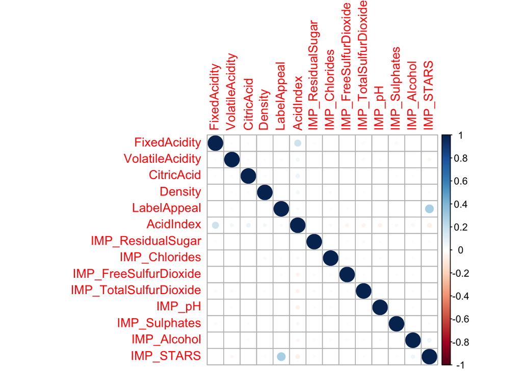

```r
clean_wine.cor <- cor(clean_wine)
corrplot(clean_wine.cor, method = "circle")
```

```r
apply(clean_wine,MARGIN=2,FUN=median)
```

```
##           FixedAcidity        VolatileAcidity             CitricAcid
##                6.90000                0.28000                0.31000
##                Density            LabelAppeal              AcidIndex
##                0.99449                0.00000                8.00000
##      IMP_ResidualSugar          IMP_Chlorides  IMP_FreeSulfurDioxide
##                3.90000                0.04600               30.00000
## IMP_TotalSulfurDioxide                 IMP_pH          IMP_Sulphates
##              123.00000                3.20000                0.50000
##            IMP_Alcohol              IMP_STARS
##               10.40000                2.00000
```

```r
head(clean_wine)
```

| FixedAcidity | VolatileAcidity | CitricAcid | Density | LabelAppeal | AcidIndex | IMP_ResidualSugar | IMP_Chlorides | IMP_FreeSulfurDioxide | IMP_TotalSulfurDioxide | IMP_pH | IMP_Sulphates | IMP_Alcohol | IMP_STARS |
| --- | --- | --- | --- | --- | --- | --- | --- | --- | --- | --- | --- | --- | --- |
| 3.2 | 1.160 | -0.98 | 0.99280 | 0 | 8 | 54.2 | -0.567 | 30 | 268 | 3.33 | -0.59 | 9.9 | 2 |
| 4.5 | 0.160 | -0.81 | 1.02792 | -1 | 7 | 26.1 | -0.425 | 15 | -327 | 3.38 | 0.70 | 10.4 | 3 |
| 7.1 | 2.640 | -0.88 | 0.99518 | -1 | 8 | 14.8 | 0.037 | 214 | 142 | 3.12 | 0.48 | 22.0 | 3 |
| 5.7 | 0.385 | 0.04 | 0.99640 | -1 | 6 | 18.8 | -0.425 | 22 | 115 | 2.24 | 1.83 | 6.2 | 1 |
| 8.0 | 0.330 | -1.26 | 0.99457 | 0 | 9 | 9.4 | 0.046 | -167 | 108 | 3.12 | 1.77 | 13.7 | 2 |
| 11.3 | 0.320 | 0.59 | 0.99940 | 0 | 11 | 2.2 | 0.556 | -37 | 15 | 3.20 | 1.29 | 15.4 | 2 |

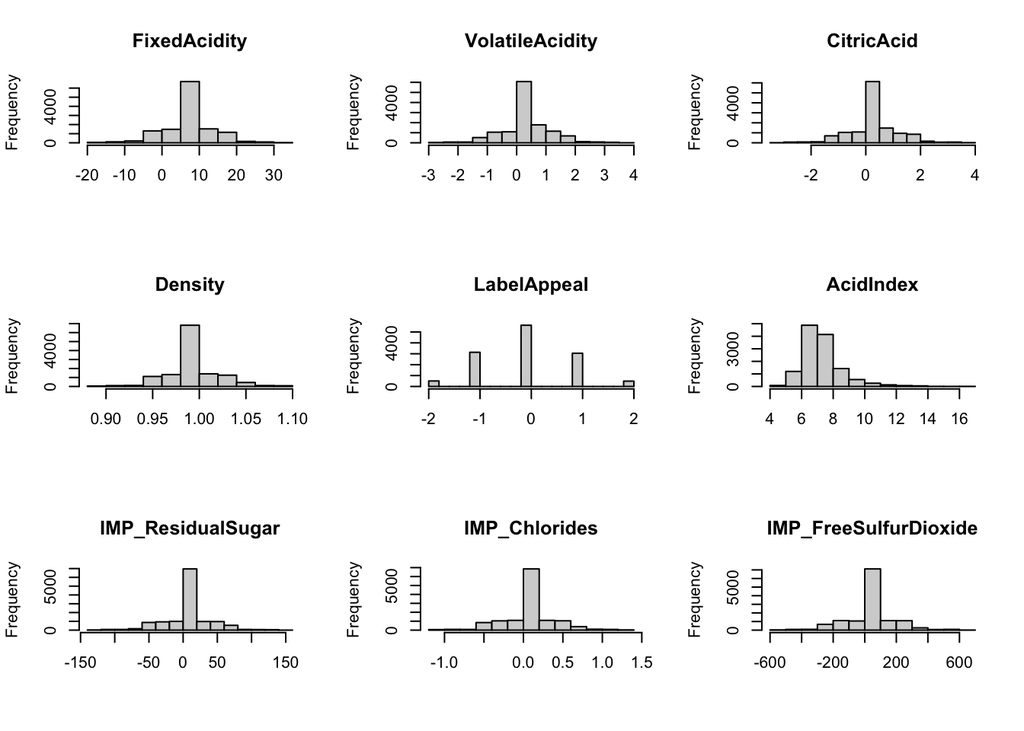

```r
cols = colnames(clean_wine)

par(mfrow=c(3,3))
for (col in cols) {
  hist(clean_wine[[col]], main = col, xlab = "")
}
```

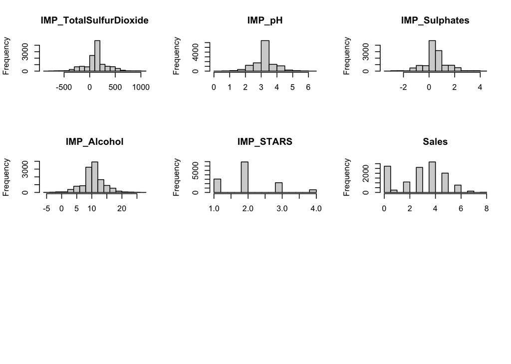

```r
hist(wine$TARGET, main = "Sales", xlab= "")
```

#### PCA Attempt

- Scale the data accordingly

```r
# scale values between 0 and 1
scaled.wine <- apply(clean_wine, MARGIN = 2, FUN = function(X) (X - min(X, na.rm = TRUE)) / diff(range(X, na.rm = TRUE, na.rm = TRUE)))

# Run PCA, do not need to center and scale, already done
wine.pca <- prcomp(scaled.wine, center = FALSE, scale. = FALSE)
summary(wine.pca)
```

```
## Importance of components:
##                           PC1     PC2     PC3     PC4     PC5     PC6     PC7
## Standard deviation     1.7697 0.26629 0.19777 0.12786 0.12615 0.12313 0.12278
## Proportion of Variance 0.9214 0.02086 0.01151 0.00481 0.00468 0.00446 0.00444
## Cumulative Proportion  0.9214 0.94231 0.95382 0.95863 0.96331 0.96777 0.97221
##                            PC8     PC9    PC10    PC11    PC12    PC13    PC14
## Standard deviation     0.12186 0.12120 0.12034 0.11872 0.11781 0.11589 0.09502
## Proportion of Variance 0.00437 0.00432 0.00426 0.00415 0.00408 0.00395 0.00266
## Cumulative Proportion  0.97658 0.98090 0.98516 0.98931 0.99339 0.99734 1.00000
```

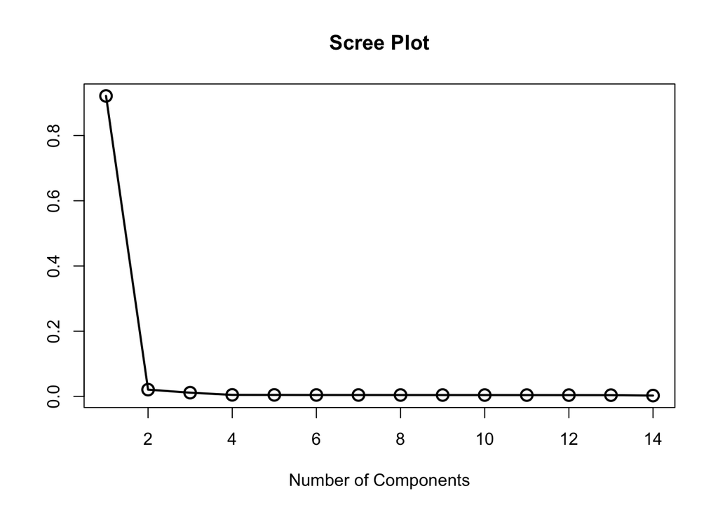

```r
# Visualize Scree Plot
scree.values <- (wine.pca$sdev^2)/sum(wine.pca$sdev^2);
plot(scree.values,xlab='Number of Components',ylab='',type='l',lwd=2)
points(scree.values,lwd=2,cex=1.5)
title('Scree Plot')
```

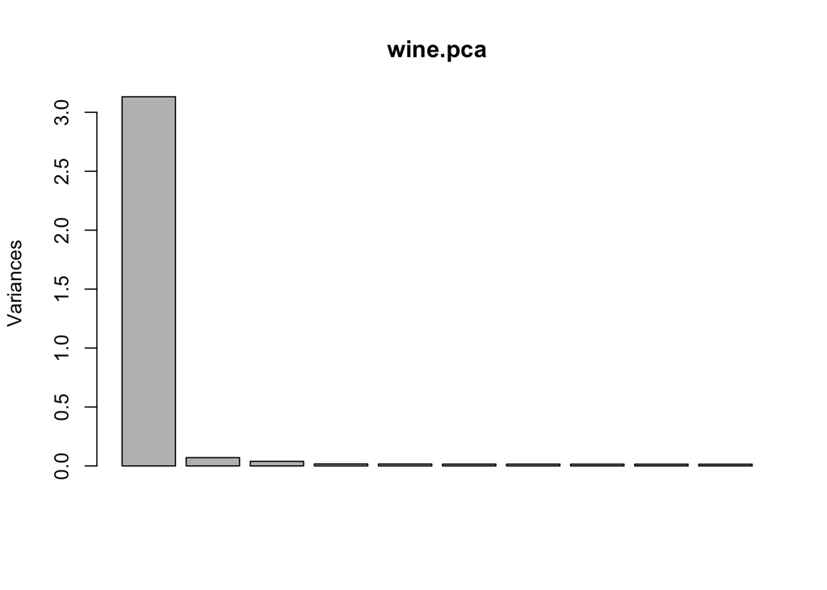

```r
plot(wine.pca)
```

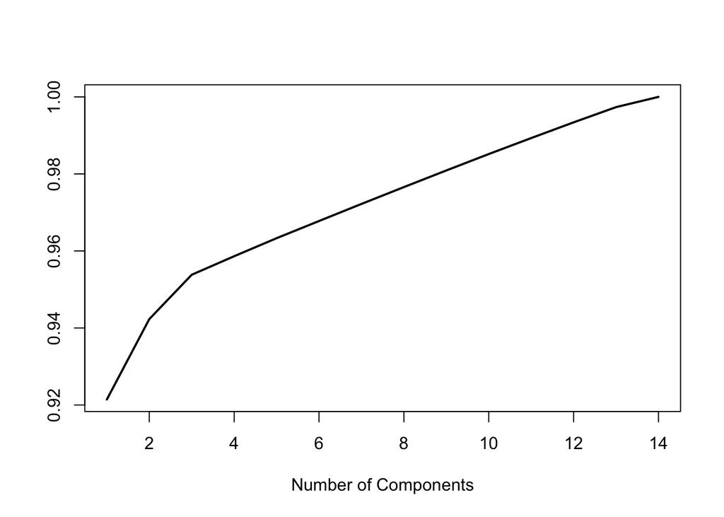

```r
variance.values <- cumsum(wine.pca$sdev^2)/sum(wine.pca$sdev^2)

plot(variance.values,xlab='Number of Components',ylab='',type='l',lwd=2)
```

- The scree plot, along with the visuals highlighting explained variance indicates that the first two PCAs can represent most of our data set (~94%)

#### Below we take a look at some elbow plots to give us an idea of the appropriate amount of clusters needed

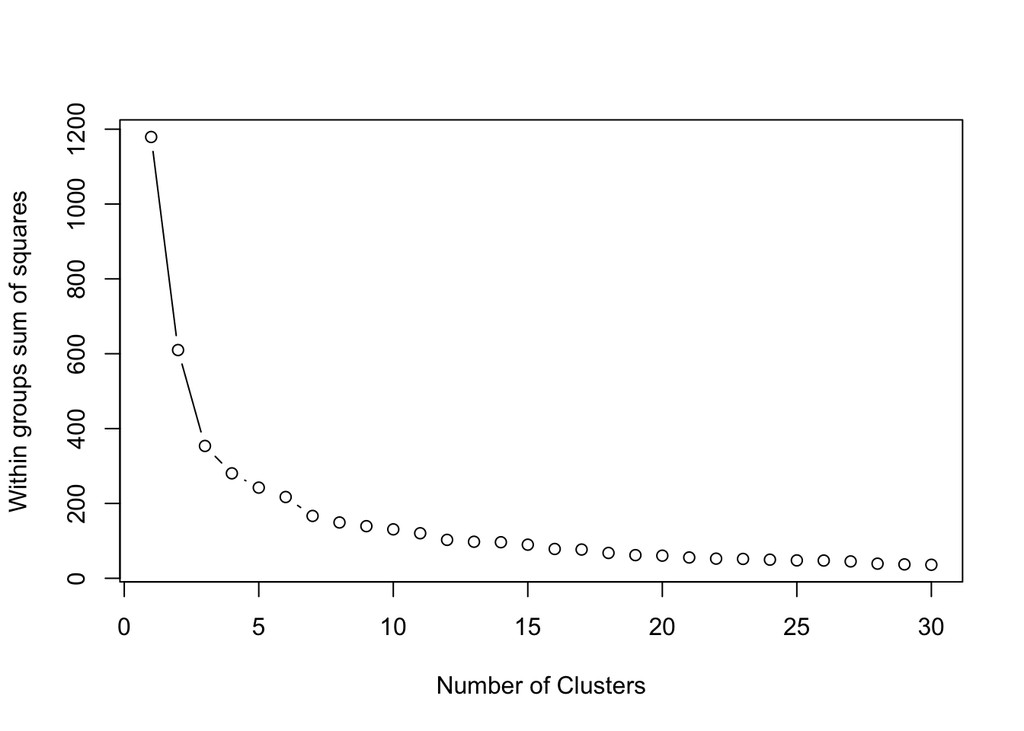

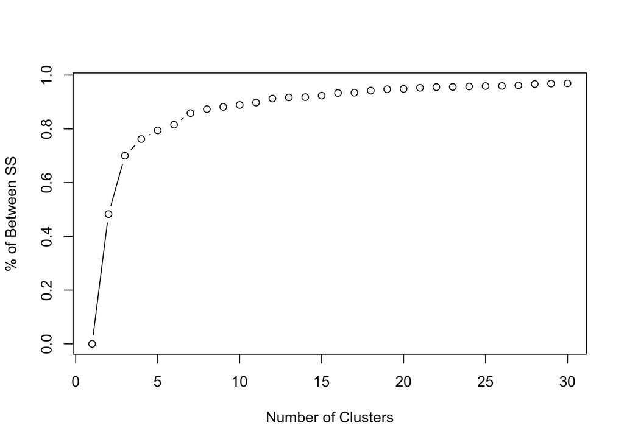

```r
# Grab first 2 principal components scores
wine_pca <- wine.pca$x[,1:2]

# accuracy - Between % ss
subdat <- wine_pca
# Elbow plot
wssplot <- function(subdat, nc=30, seed=1234) {
  wss <- (nrow(subdat)-1)*sum(apply(subdat,2,var))
  for (i in 2:nc) {
    set.seed(seed)
    k <- kmeans(subdat, centers=i,iter.max = 50)
    wss[i] <- sum(kmeans(subdat, centers=i,iter.max = 50)$withinss)}
    rs <- (wss[1] - wss)/wss[1]
    plot(1:nc, wss, type="b", xlab="Number of Clusters",
         ylab="Within groups sum of squares")
    plot(1:nc, rs, type="b", xlab="Number of Clusters",
       ylab="% of Between SS")
    }

wssplot(subdat)
```

- the above shows that changes in sum of square differences begins to ‘elbow’ around 3 & 5 clusters, while becoming relatively consistent around 10

#### We will also leverage brute force calculation to test accuracy as cluster count increases

```r
# Brute force check which # of clusters results in most appropriate accuracy
for (i in seq(1,10)) {
  set.seed(123)
  wine.kmean <- kmeans(wine_pca, i, iter.max = 500)
  accuracy <- wine.kmean$betweenss/wine.kmean$totss
  cat("Accuracy for", i, "clusters: ", round((accuracy*100)),"%\n")
}
```

```
## Accuracy for 1 clusters:  0 %
## Accuracy for 2 clusters:  53 %
## Accuracy for 3 clusters:  69 %
## Accuracy for 4 clusters:  76 %
## Accuracy for 5 clusters:  79 %
## Accuracy for 6 clusters:  82 %
## Accuracy for 7 clusters:  86 %
## Accuracy for 8 clusters:  87 %
## Accuracy for 9 clusters:  88 %
## Accuracy for 10 clusters:  89 %
```

```r
# Create and fit kmeans model
set.seed(123)
k <- 10
wine.kmean <- kmeans(wine_pca, k, iter.max = 500)

# See how many observations per cluster
df.count <- as.data.frame(cbind(wine.kmean$cluster, wine$INDEX))
colnames(df.count) <- c("cluster","index")
df.count %>% count(cluster)
```

| cluster | n |
| --- | --- |
| 1 | 1421 |
| 2 | 2425 |
| 3 | 1309 |
| 4 | 1225 |
| 5 | 1889 |
| 6 | 1226 |
| 7 | 678 |
| 8 | 1188 |
| 9 | 735 |
| 10 | 699 |

- we see that around 7 clusters, differences begin to drop significantly. I chose 10 clusters as I felt comfortable with the accuracy score

#### Below we visualize the 10 clusters leverage the first two principal components which explain around 94% of variance within our data set

```r
library(ggpubr)
library(factoextra)
```

```r
# gather coordinates
wine.km.viz <- as.data.frame(get_pca_ind(wine.pca)$coord)

# Bring cluster assignments back to each record
wine.km.viz$cluster <- factor(wine.kmean$cluster)
head(wine.km.viz)
```

|  | Dim.1 | Dim.2 | Dim.3 | Dim.4 | Dim.5 | Dim.6 | Dim.7 | Dim.8 | Dim.9 | Dim.10 | Dim.11 | Dim.12 | Dim.13 | Dim.14 | cluster |
| --- | --- | --- | --- | --- | --- | --- | --- | --- | --- | --- | --- | --- | --- | --- | --- |
| 1 | -1.690484 | -0.004798657 | 0.010879974 | -0.209433673 | 5.279220e-02 | 0.17983024 | -0.084760730 | -0.168769141 | -0.163508467 | 0.082853326 | 0.124415691 | -0.01433854 | -0.057709841 | -0.07794497 | 1 |
| 2 | -1.640185 | -0.198819195 | -0.353255998 | -0.021708105 | 1.132491e-01 | 0.24901351 | -0.051910489 | -0.008581452 | -0.116062044 | 0.008788183 | -0.212029409 | -0.06493402 | -0.005150902 | 0.01265950 | 1 |
| 3 | -1.962091 | -0.098803103 | -0.415100069 | -0.008112861 | 7.945479e-03 | 0.18371127 | -0.242952840 | -0.091716973 | 0.142575462 | 0.141573467 | 0.108971064 | -0.23112541 | -0.230406541 | -0.05400637 | 8 |
| 4 | -1.513551 | 0.373237993 | -0.038797721 | -0.074707143 | -5.617909e-02 | 0.12614361 | 0.001232791 | 0.038926871 | -0.113196696 | -0.111742913 | 0.047473733 | -0.15547633 | 0.156868468 | 0.14269360 | 3 |
| 5 | -1.746370 | 0.013443770 | 0.005622377 | 0.104797936 | 5.558924e-02 | 0.04920687 | -0.174826834 | -0.007149041 | -0.077966503 | -0.223126367 | 0.009070886 | -0.07850330 | -0.090535092 | -0.09136433 | 2 |
| 6 | -1.934156 | 0.076823610 | -0.014864621 | 0.235892433 | 1.608564e-05 | -0.11666103 | -0.036367045 | 0.035410020 | 0.009369794 | -0.051024109 | -0.072193751 | -0.05833954 | -0.073995267 | -0.17312864 | 8 |

```r
# Check the % variance explained by each princpal component
ev <- round(get_eigenvalue(wine.pca), 2)
variance.percent <- ev$variance.percent
head(ev)
```

|  | eigenvalue | variance.percent | cumulative.variance.percent |
| --- | --- | --- | --- |
| Dim.1 | 3.13 | 92.14 | 92.14 |
| Dim.2 | 0.07 | 2.09 | 94.23 |
| Dim.3 | 0.04 | 1.15 | 95.38 |
| Dim.4 | 0.02 | 0.48 | 95.86 |
| Dim.5 | 0.02 | 0.47 | 96.33 |
| Dim.6 | 0.02 | 0.45 | 96.78 |

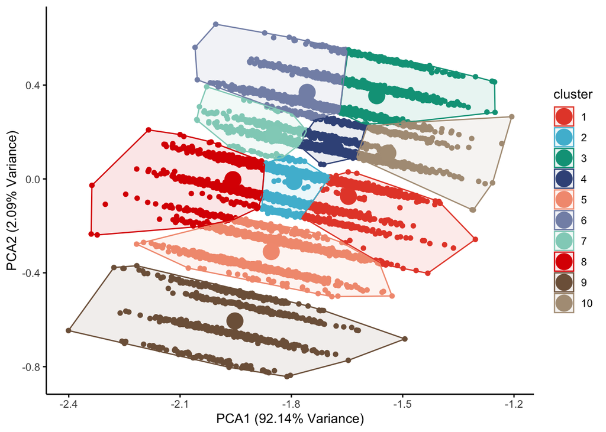

```r
# visualize the first two PCAs
ggscatter(
  wine.km.viz, x = "Dim.1", y = "Dim.2",
  color = "cluster", palette = "npg", ellipse = TRUE, ellipse.type = "convex",
  size = 1.5,  legend = "right", ggtheme = theme_classic(),
  xlab = paste0("PCA1 (", variance.percent[1], "% Variance)" ),
  ylab = paste0("PCA2 (", variance.percent[2], "% Variance)" )
) +
  stat_mean(aes(color = cluster), size = 6)
```

```r
# Bring clusters, index, and target back to the clean wine data set for further analysis
wine.final <- cbind(wine[,c(1,2)], wine.kmean$cluster, clean_wine)

columns <- colnames(wine.final)
columns[3] <- "Cluster"
colnames(wine.final) <- columns

by_cluster <- wine.final %>% group_by(Cluster)

by_cluster %>% summarise(
  stars = mean(IMP_STARS),
  stars.m = median(IMP_STARS),
  sales = mean(TARGET),
  sales.m = median(TARGET),
  n = n()
)
```

| Cluster | stars | stars.m | sales | sales.m | n |
| --- | --- | --- | --- | --- | --- |
| 1 | 2.128079 | 2 | 2.938776 | 4 | 1421 |
| 2 | 2.030928 | 2 | 2.807010 | 3 | 2425 |
| 3 | 1.001528 | 1 | 2.469824 | 3 | 1309 |
| 4 | 1.833469 | 2 | 2.132245 | 2 | 1225 |
| 5 | 2.947062 | 3 | 4.541556 | 5 | 1889 |
| 6 | 1.037520 | 1 | 2.471452 | 3 | 1226 |
| 7 | 1.646018 | 2 | 2.202065 | 2 | 678 |
| 8 | 2.040404 | 2 | 2.713805 | 4 | 1188 |
| 9 | 3.793197 | 4 | 5.565986 | 6 | 735 |
| 10 | 1.875536 | 2 | 2.163090 | 2 | 699 |

```r
#write.csv(wine.final, "final_wine.csv")
```